# Latihan MPDW Pertemuan 5

Windi Gunawan

2023-09-26

# Memanggil Packages yang digunakan

```r
library(dplyr)
library(TTR)
library(forecast)
library(lmtest) #untuk uji formal pendeteksian autokorelasi
```

```r
library(orcutt) #untuk membuat model regresi Cochrane-Orcutt
library(HoRM) #untuk membuat model regresi Hildreth-Lu
library(corrplot)
library(ggplot2)
library(tsibble)
library(tseries)
library(MASS)
```

## Input Data

```r
data <- read.csv("https://raw.githubusercontent.com/Windi82/MPDWP1/main/Pertemuan%202/bajajfinance.csv")
head(data,10)
```

```
##         date  close   high    low   open  volume    sma5   sma10    sma15
## 1   4/7/2015 434.12 436.50 421.03 427.50  184490 416.608 406.580 405.3407
## 2   4/8/2015 448.92 453.00 428.56 434.12  188240 426.398 411.542 408.5680
## 3   4/9/2015 450.47 469.90 440.01 454.20  535180 434.322 416.908 411.7067
## 4  4/10/2015 452.21 459.80 447.88 453.00  324510 441.962 422.647 414.8667
## 5  4/13/2015 445.38 452.21 442.00 452.21  300820 446.220 427.619 417.6553
## 6  4/15/2015 445.60 448.98 437.70 445.50  383270 448.516 432.562 420.5587
## 7  4/16/2015 458.50 460.50 437.50 447.23  104480 450.432 438.415 424.5053
## 8  4/17/2015 452.95 460.51 444.13 458.00  187220 450.928 442.625 428.2480
## 9  4/20/2015 455.83 459.40 443.87 447.29  190990 451.652 446.807 432.3153
## 10 4/21/2015 437.34 455.00 413.93 450.50 1257380 450.044 448.132 435.0940
##       sma20     ema5    ema10    ema15    ema20 upperband middleband lowerband
## 1  407.8915 419.5083 412.8633 411.0694 410.3932  439.9211    416.608  393.2949
## 2  409.2630 429.3122 419.4191 415.8007 414.0624  454.2174    426.398  398.5786
## 3  410.8740 436.3648 425.0647 420.1343 417.5298  462.4811    434.322  406.1629
```

[output cut: 73 more lines]

```r
str(data)
```

```
## 'data.frame':    1859 obs. of  60 variables:
##  $ date        : chr  "4/7/2015" "4/8/2015" "4/9/2015" "4/10/2015" ...
##  $ close       : num  434 449 450 452 445 ...
##  $ high        : num  436 453 470 460 452 ...
##  $ low         : num  421 429 440 448 442 ...
##  $ open        : num  428 434 454 453 452 ...
##  $ volume      : int  184490 188240 535180 324510 300820 383270 104480 187220 190990 1257380 ...
##  $ sma5        : num  417 426 434 442 446 ...
##  $ sma10       : num  407 412 417 423 428 ...
##  $ sma15       : num  405 409 412 415 418 ...
##  $ sma20       : num  408 409 411 413 414 ...
##  $ ema5        : num  420 429 436 442 443 ...
##  $ ema10       : num  413 419 425 430 433 ...
##  $ ema15       : num  411 416 420 424 427 ...
##  $ ema20       : num  410 414 418 421 423 ...
```

[output cut: 46 more lines]

# Ubah format tanggal

```r
date <- as.Date(data$date, format="%m/%d/%Y")
date <- substr(date, 1,4)
head(date)
```

```
## [1] "2015" "2015" "2015" "2015" "2015" "2015"
```

# Membuat dataframe yang diperlukan

Data yang digunakan dalam kesempatan kali ini adalah data Bajaj Finance Periode 2022.

```r
#Peubah yang digunakan
high <- data$high
head(high)
```

```
## [1] 436.50 453.00 469.90 459.80 452.21 448.98
```

```r
#Menggabungkan data
datagabung <- cbind.data.frame(date,high)

#Ambil data periode 2022 saja
datagabung <- datagabung[date == "2022",]
datagabung
```

```
##      date    high
## 1660 2022 7243.95
## 1661 2022 7375.00
## 1662 2022 7691.15
## 1663 2022 7779.35
## 1664 2022 7785.00
## 1665 2022 7759.00
## 1666 2022 7759.95
## 1667 2022 7869.00
## 1668 2022 7849.55
## 1669 2022 7846.10
## 1670 2022 7910.00
## 1671 2022 7945.00
## 1672 2022 8045.00
## 1673 2022 7650.00
```

[output cut: 186 more lines]

# Ubah data menjadi data time series

```r
high.ts <- ts(datagabung$high)
high.ts
```

```
## Time Series:
## Start = 1
## End = 200
## Frequency = 1
##   [1] 7243.95 7375.00 7691.15 7779.35 7785.00 7759.00 7759.95 7869.00 7849.55
##  [10] 7846.10 7910.00 7945.00 8045.00 7650.00 7499.00 7350.00 6996.00 6902.35
##  [19] 7045.60 7075.90 7115.80 7280.00 7287.05 7188.40 7165.00 7147.00 7157.90
##  [28] 7240.00 7079.95 6930.00 7195.00 7224.95 7128.00 7116.00 7080.90 7036.15
##  [37] 7117.35 6900.20 6989.95 7025.00 6936.35 6944.30 6698.00 6370.00 6217.35
##  [46] 6525.00 6794.00 6685.00 6689.00 6750.00 6899.40 7056.90 7018.75 7010.00
##  [55] 7104.00 7035.55 7067.45 7035.00 7060.00 7274.45 7445.00 7449.00 7590.90
##  [64] 7479.95 7425.00 7356.00 7425.00 7384.00 7299.95 7380.00 7375.00 7443.30
##  [73] 7294.70 7187.00 7207.00 7074.95 7262.95 7100.00 6805.00 6823.60 6649.85
##  [82] 6667.80 6497.45 6205.05 6135.25 6113.05 5996.60 5764.75 5749.00 5711.95
##  [91] 5849.00 5956.70 5745.00 5841.95 5906.25 5833.00 5877.70 5875.45 6077.00
## [100] 6127.00 6169.20 6130.00 6080.00 6168.00 6050.00 5989.95 6054.00 5931.60
## [109] 5835.00 5554.00 5461.00 5499.90 5614.95 5475.00 5510.00 5564.00 5531.50
## [118] 5495.00 5616.65 5725.00 5619.00 5554.00 5535.20 5633.95 5648.95 5755.00
## [127] 5938.85 5986.90 5928.00 5903.95 5959.55 5979.00 5926.95 5928.25 6068.10
## [136] 6098.15 6149.60 6283.15 6325.00 6334.00 6383.70 6429.40 7109.95 7260.00
## [145] 7310.00 7356.00 7376.40 7385.00 7367.95 7398.00 7369.00 7325.00 7343.00
## [154] 7384.00 7638.00 7588.80 7538.70 7279.80 7250.00 7236.40 7239.00 7141.50
## [163] 7015.50 7335.00 7333.85 7313.00 7254.00 7255.00 7207.95 7279.45 7324.00
## [172] 7319.90 7444.00 7560.00 7532.85 7480.15 7524.45 7715.00 7735.00 7778.00
## [181] 7731.50 7460.00 7379.95 7297.50 7316.90 7362.00 7398.00 7505.00 7599.00
## [190] 7407.75 7338.00 7352.50 7258.50 7226.00 7345.00 7372.30 7430.00 7440.00
## [199] 7449.00 7490.00
```

### Plot *Time Series*

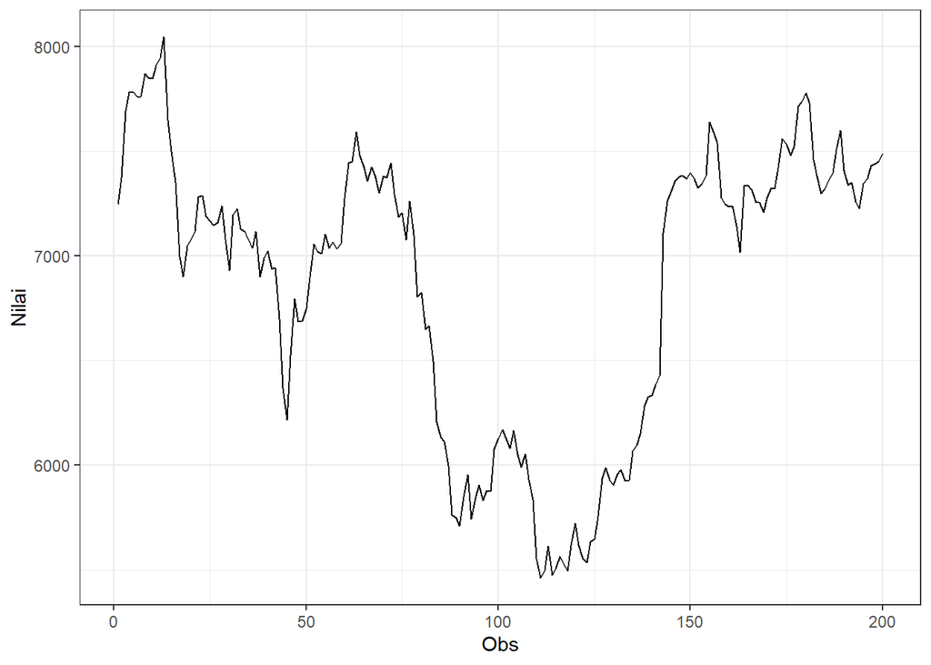

```r
plot_high.ts <- high.ts |> as_tsibble() |>
  ggplot(aes(x = index, y = value)) + geom_line() + theme_bw() +
  xlab("Obs") + ylab("Nilai")
plot_high.ts
```

```r
mean(high.ts)
```

```
## [1] 6863.13
```

Berdasarkan plot time series tersebut, terlihat bahwa data tidak stasioner dalam rataan, ditandai dengan adanya trend pada data dan tidak stasioner dalam ragam, ditandai dengan adanya perbedaan lebar pita pada plot.

### Plot ACF

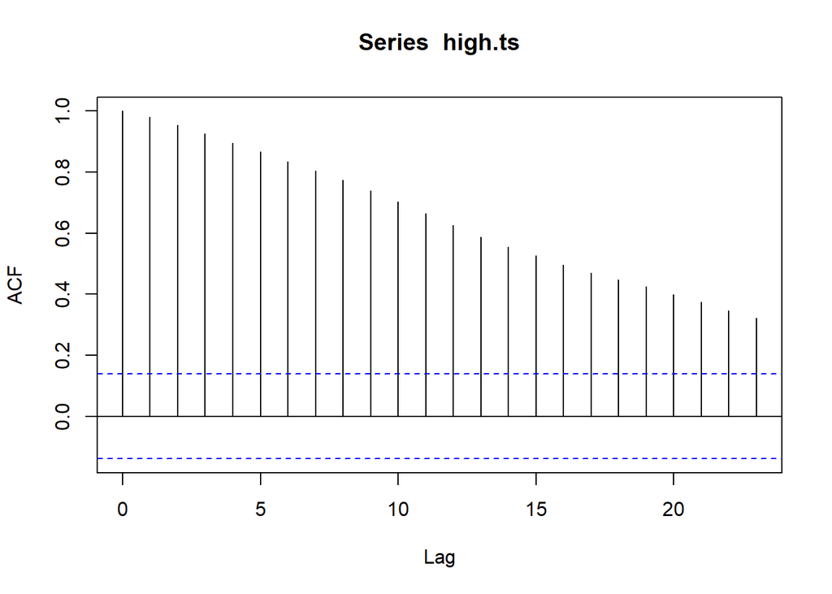

```r
acf(high.ts)
```

Berdasarkan plot ACF, terlihat bahwa plot ACF pada data tersebut menurun secara perlahan (*tails off slowly*) yang menandakan data tidak stasioner dalam rataan.

### Uji ADF

```r
adf.test(high.ts)
```

```
##
##  Augmented Dickey-Fuller Test
##
## data:  high.ts
## Dickey-Fuller = -1.8607, Lag order = 5, p-value = 0.6344
## alternative hypothesis: stationary
```

$H_0$ : Data tidak stasioner dalam rataan

$H_1$ : Data stasioner dalam rataan

Berdasarkan uji ADF tersebut, didapat *p-value* sebesar 0.6344 yang lebih besar dari taraf nyata 5% dan menandakan bahwa data tidak stasioner dalam rataan. Hal ini sesuai dengan hasil eksplorasi menggunakan plot time series dan plot ACF.

### Plot Box-Cox

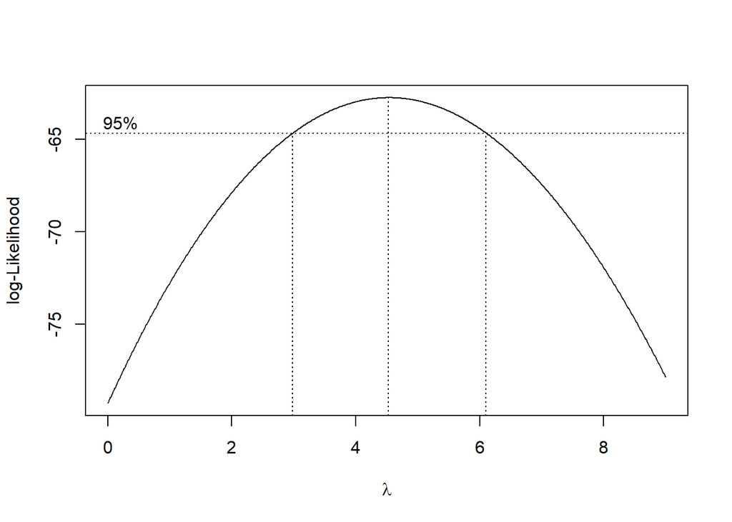

```r
index <- seq(1:200)
bc = boxcox(high.ts~index, lambda = seq(0,9,by=0.01))
```

```r
#Nilai Rounded Lambda
lambda <- bc$x[which.max(bc$y)]
lambda
```

```
## [1] 4.53
```

```r
#SK
bc$x[bc$y > max(bc$y) - 1/2 * qchisq(.95,1)]
```

```
##   [1] 2.99 3.00 3.01 3.02 3.03 3.04 3.05 3.06 3.07 3.08 3.09 3.10 3.11 3.12 3.13
##  [16] 3.14 3.15 3.16 3.17 3.18 3.19 3.20 3.21 3.22 3.23 3.24 3.25 3.26 3.27 3.28
##  [31] 3.29 3.30 3.31 3.32 3.33 3.34 3.35 3.36 3.37 3.38 3.39 3.40 3.41 3.42 3.43
##  [46] 3.44 3.45 3.46 3.47 3.48 3.49 3.50 3.51 3.52 3.53 3.54 3.55 3.56 3.57 3.58
##  [61] 3.59 3.60 3.61 3.62 3.63 3.64 3.65 3.66 3.67 3.68 3.69 3.70 3.71 3.72 3.73
##  [76] 3.74 3.75 3.76 3.77 3.78 3.79 3.80 3.81 3.82 3.83 3.84 3.85 3.86 3.87 3.88
##  [91] 3.89 3.90 3.91 3.92 3.93 3.94 3.95 3.96 3.97 3.98 3.99 4.00 4.01 4.02 4.03
## [106] 4.04 4.05 4.06 4.07 4.08 4.09 4.10 4.11 4.12 4.13 4.14 4.15 4.16 4.17 4.18
## [121] 4.19 4.20 4.21 4.22 4.23 4.24 4.25 4.26 4.27 4.28 4.29 4.30 4.31 4.32 4.33
## [136] 4.34 4.35 4.36 4.37 4.38 4.39 4.40 4.41 4.42 4.43 4.44 4.45 4.46 4.47 4.48
## [151] 4.49 4.50 4.51 4.52 4.53 4.54 4.55 4.56 4.57 4.58 4.59 4.60 4.61 4.62 4.63
## [166] 4.64 4.65 4.66 4.67 4.68 4.69 4.70 4.71 4.72 4.73 4.74 4.75 4.76 4.77 4.78
## [181] 4.79 4.80 4.81 4.82 4.83 4.84 4.85 4.86 4.87 4.88 4.89 4.90 4.91 4.92 4.93
## [196] 4.94 4.95 4.96 4.97 4.98 4.99 5.00 5.01 5.02 5.03 5.04 5.05 5.06 5.07 5.08
## [211] 5.09 5.10 5.11 5.12 5.13 5.14 5.15 5.16 5.17 5.18 5.19 5.20 5.21 5.22 5.23
## [226] 5.24 5.25 5.26 5.27 5.28 5.29 5.30 5.31 5.32 5.33 5.34 5.35 5.36 5.37 5.38
## [241] 5.39 5.40 5.41 5.42 5.43 5.44 5.45 5.46 5.47 5.48 5.49 5.50 5.51 5.52 5.53
## [256] 5.54 5.55 5.56 5.57 5.58 5.59 5.60 5.61 5.62 5.63 5.64 5.65 5.66 5.67 5.68
## [271] 5.69 5.70 5.71 5.72 5.73 5.74 5.75 5.76 5.77 5.78 5.79 5.80 5.81 5.82 5.83
## [286] 5.84 5.85 5.86 5.87 5.88 5.89 5.90 5.91 5.92 5.93 5.94 5.95 5.96 5.97 5.98
## [301] 5.99 6.00 6.01 6.02 6.03 6.04 6.05 6.06 6.07 6.08 6.09 6.10
```

Gambar di atas menunjukkan nilai *rounded value* ($\lambda$) optimum sebesar **4,53** dan pada selang kepercayaan 95% nilai memiliki batas bawah **2,99** dan batas atas **6,10**. Selang tersebut tidak memuat nilai satu sehingga dapat dikatakan bahwa data tersebut tidak stasioner dalam ragam.

### Partisi Data

#### Bagian 1

```r
high.ts1 <- high.ts[1:140] |> ts()
mean(high.ts1)
```

```
## [1] 6652.503
```

```r
var(high.ts1)
```

```
## [1] 523624.9
```

#### Plot Time Series

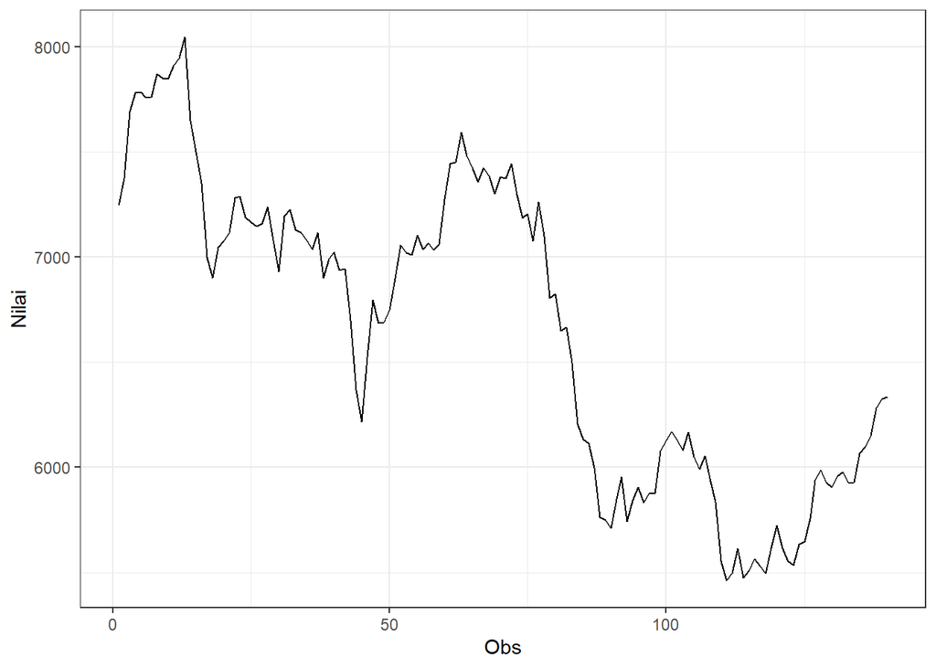

```r
high.ts1 |> as_tsibble() |>
  ggplot(aes(x = index, y = value)) +
  geom_line() + theme_bw() +
  xlab("Obs") + ylab("Nilai")
```

Berdasarkan plot time series tersebut, terlihat bahwa data tidak stasioner dalam rataan karena masih terdapat tren pada data, namun cenderung stasioner dalam ragam karena memiliki lebar pita yang cenderung sama.

#### Plot ACF

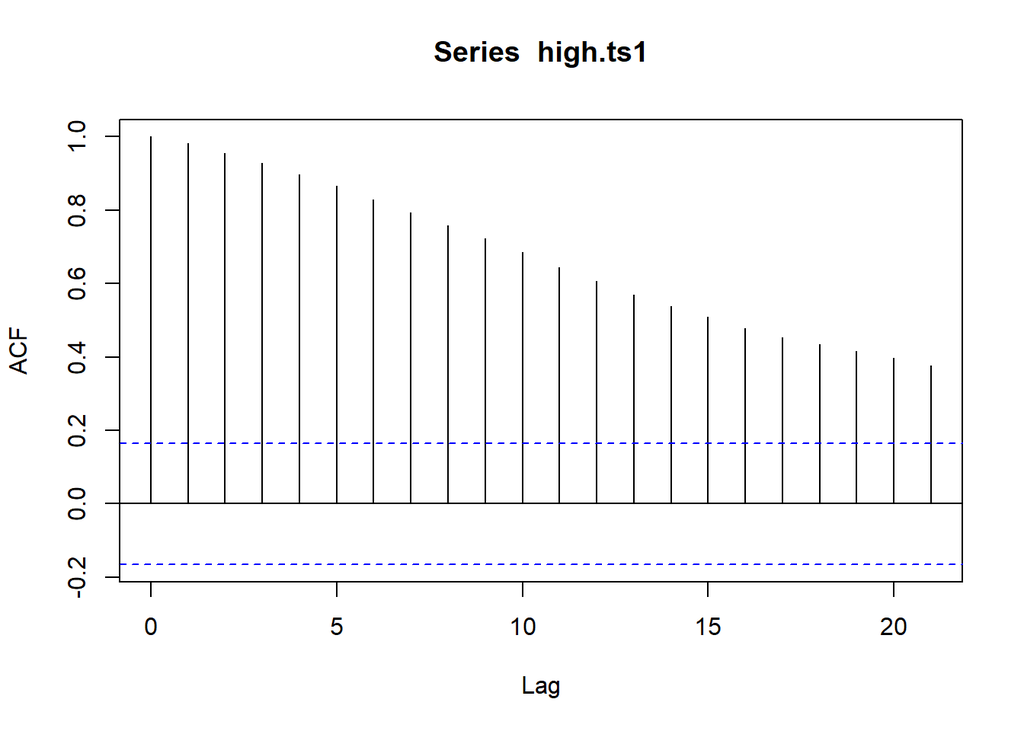

```r
acf(high.ts1)
```

Berdasarkan plot ACF, terlihat bahwa plot ACF pada data tersebut menurun secara perlahan (*tails off slowly*) yang menandakan data tidak stasioner dalam rataan

#### Uji ADF

```r
adf.test(high.ts1)
```

```
##
##  Augmented Dickey-Fuller Test
##
## data:  high.ts1
## Dickey-Fuller = -2.3803, Lag order = 5, p-value = 0.4182
## alternative hypothesis: stationary
```

$H_0$ : Data tidak stasioner dalam rataan

$H_1$ : Data stasioner dalam rataan

Berdasarkan uji ADF tersebut, didapat *p-value* sebesar 0.4182 yang lebih besar dari taraf nyata 5% dan menandakan bahwa data tidak stasioner dalam rataan. Hal ini sesuai dengan hasil eksplorasi menggunakan plot time series dan plot ACF

### Plot Box-Cox

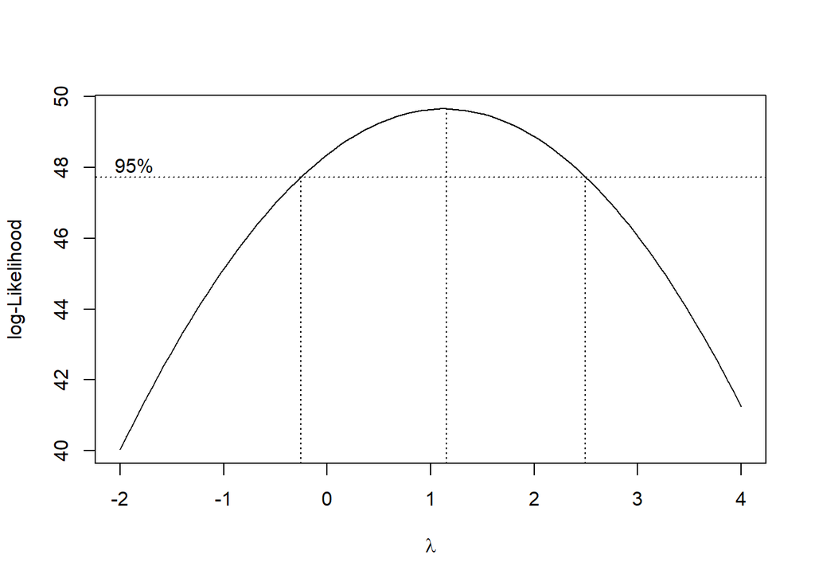

```r
index <- seq(1:140)
bc = boxcox(high.ts1~index, lambda = seq(-2,4,by=0.1))
```

```r
#Nilai Rounded Lambda
lambda <- bc$x[which.max(bc$y)]
lambda
```

[output not shown]

```r
#SK
bc$x[bc$y > max(bc$y) - 1/2 * qchisq(.95,1)]
```

[output not shown]

#### Bagian 2

```r
high.ts2 <- high.ts[1:70] |> ts()
mean(high.ts2)
```

```
## [1] 7216.954
```

```r
var(high.ts2)
```

```
## [1] 140210.2
```

#### Plot Time Series

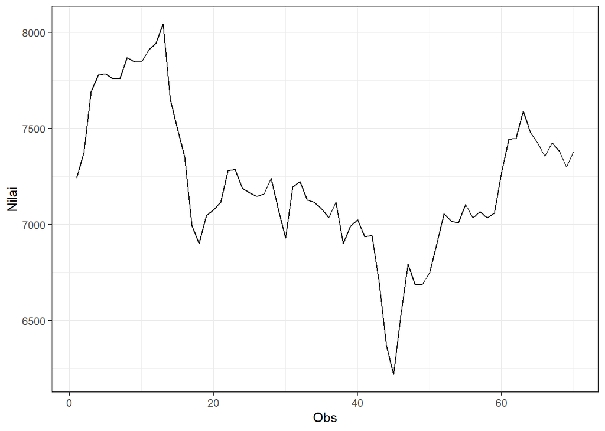

```r
high.ts2 |> as_tsibble() |>
  ggplot(aes(x = index, y = value)) +
  geom_line() + theme_bw() +
  xlab("Obs") + ylab("Nilai")
```

Berdasarkan plot time series tersebut, terlihat bahwa data tidak stasioner dalam rataan karena masih terdapat tren pada data, namun stasioner dalam ragam karena memiliki lebar pita yang cenderung sama

#### Plot ACF

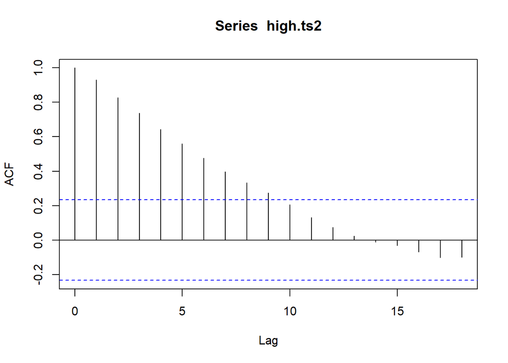

```r
acf(high.ts2)
```

Berdasarkan plot ACF, terlihat bahwa plot ACF pada data tersebut menurun secara perlahan (*tails off slowly*) yang menandakan data tidak stasioner dalam rataan

#### Uji ADF

```r
adf.test(high.ts2)
```

```
##
##  Augmented Dickey-Fuller Test
##
## data:  high.ts2
## Dickey-Fuller = -1.4873, Lag order = 4, p-value = 0.7837
## alternative hypothesis: stationary
```

$H_0$ : Data tidak stasioner dalam rataan

$H_1$ : Data stasioner dalam rataan

Berdasarkan uji ADF tersebut, didapat *p-value* sebesar 0.7837 yang lebih besar dari taraf nyata 5% dan menandakan bahwa data tidak stasioner dalam rataan. Hal ini sesuai dengan hasil eksplorasi menggunakan plot time series dan plot ACF

### Plot Box-Cox

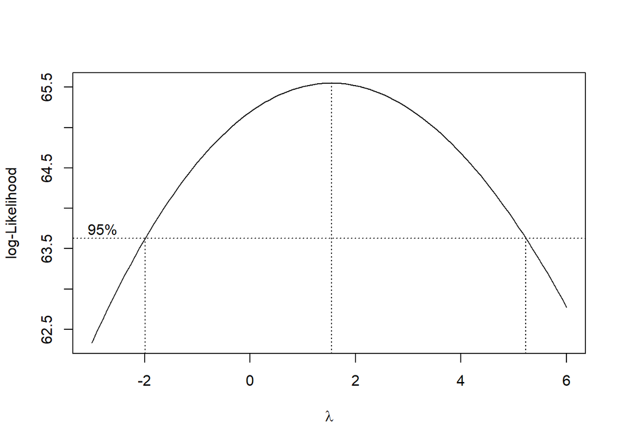

```r
index <- seq(1:70)
bc = boxcox(high.ts2~index, lambda = seq(-3,6,by=1))
```

```r
#Nilai Rounded Lambda
lambda <- bc$x[which.max(bc$y)]
lambda
```

[output not shown]

```r
#SK
bc$x[bc$y > max(bc$y) - 1/2 * qchisq(.95,1)]
```

[output not shown]

#### Bagian 3

```r
high.ts3 <- high.ts[140:200] |> ts()
mean(high.ts3)
```

```
## [1] 7337.862
```

```r
var(high.ts3)
```

```
## [1] 70290.56
```

#### Plot Time Series

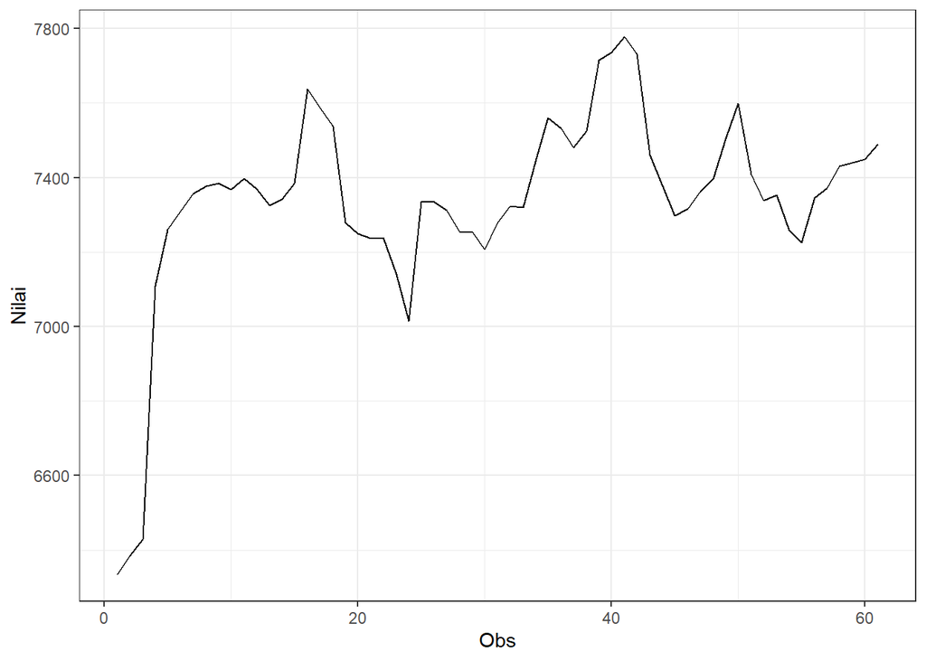

```r
high.ts3 |> as_tsibble() |>
  ggplot(aes(x = index, y = value)) +
  geom_line() + theme_bw() +
  xlab("Obs") + ylab("Nilai")
```

Plot deret waktu di atas menunjukkan bahwa data stasioner dalam rataan, ditandai dengan data yang menyebar di sekitar nilai tengahnya (7337), namun cenderung tidak stasioner dalam ragam karena memiliki lebar pita yang cenderung tidak sama.

#### Plot ACF

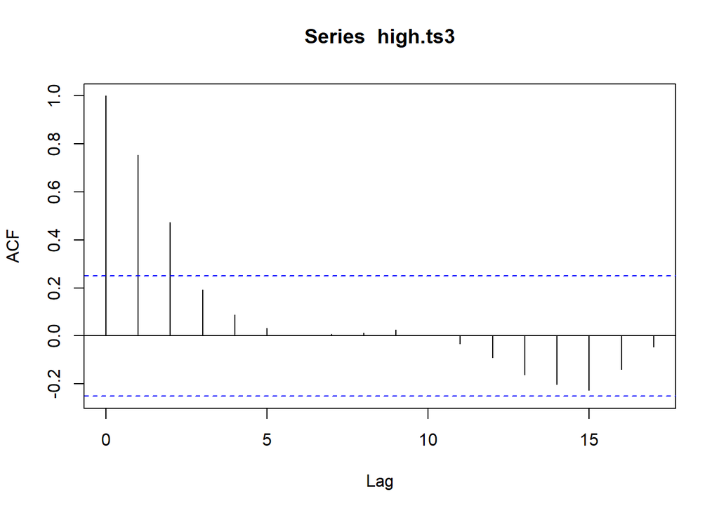

```r
acf(high.ts3)
```

Berdasarkan plot ACF, terlihat bahwa plot ACF pada data tersebut cenderung *tails off* dan membentuk gelombang sinus.

#### Uji ADF

```r
adf.test(high.ts3)
```

```
##
##  Augmented Dickey-Fuller Test
##
## data:  high.ts3
## Dickey-Fuller = -3.0615, Lag order = 3, p-value = 0.1455
## alternative hypothesis: stationary
```

$H_0$ : Data tidak stasioner dalam rataan

$H_1$ : Data stasioner dalam rataan

Berdasarkan uji ADF tersebut, didapat *p-value* sebesar 0.1455 yang lebih besar dari taraf nyata 5% dan menandakan bahwa data tidak stasioner dalam rataan. Hal ini tidak sesuai dengan hasil eksplorasi menggunakan plot time series dan plot ACF.

```r
adf.test(high.ts3, k=2)
```

```
##
##  Augmented Dickey-Fuller Test
##
## data:  high.ts3
## Dickey-Fuller = -6.1669, Lag order = 2, p-value = 0.01
## alternative hypothesis: stationary
```

Berdasarkan uji ADF yang menggunakan k=2 tersebut, didapat *p-value* sebesar 0.01 yang lebih kecil dari taraf nyata 5% dan menandakan bahwa data stasioner dalam rataan. Hal ini sesuai dengan hasil eksplorasi menggunakan plot time series dan plot ACF.

### Plot Box-Cox

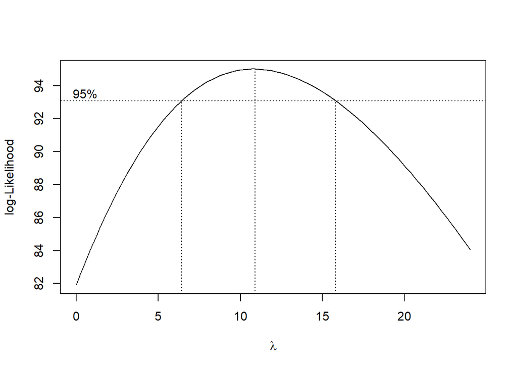

```r
index <- seq(140:200)
bc = boxcox(high.ts3~index, lambda = seq(0,25,by=2))
```

```r
#Nilai Rounded Lambda
lambda <- bc$x[which.max(bc$y)]
lambda
```

[output not shown]

```r
#SK
bc$x[bc$y > max(bc$y) - 1/2 * qchisq(.95,1)]
```

[output not shown]